# PA1_template

Monica Azqueta

Friday, April 17, 2015

## Loading and preprocessing the data

```r
setwd("~/Documents/Scientific Data/Reproducible research/Assigment1")
file <- "~/Documents/Scientific Data/Reproducible research/Assigment1/activity.csv"
activity_data <- read.csv(file)
```

## What is the mean total number of steps taken per day?

### 1.Calculate the total number of steps taken per day

We make use of the function aggregate to apply the functio sum() to the variables “steps” grouped by the factor variable “date”

```r
steps_day <- aggregate(steps ~ date, activity_data, sum)
head(steps_day)
```

```
##         date steps
## 1 2012-10-02   126
## 2 2012-10-03 11352
## 3 2012-10-04 12116
## 4 2012-10-05 13294
## 5 2012-10-06 15420
## 6 2012-10-07 11015
```

### 2.Make a histogram of the total number of steps taken each day

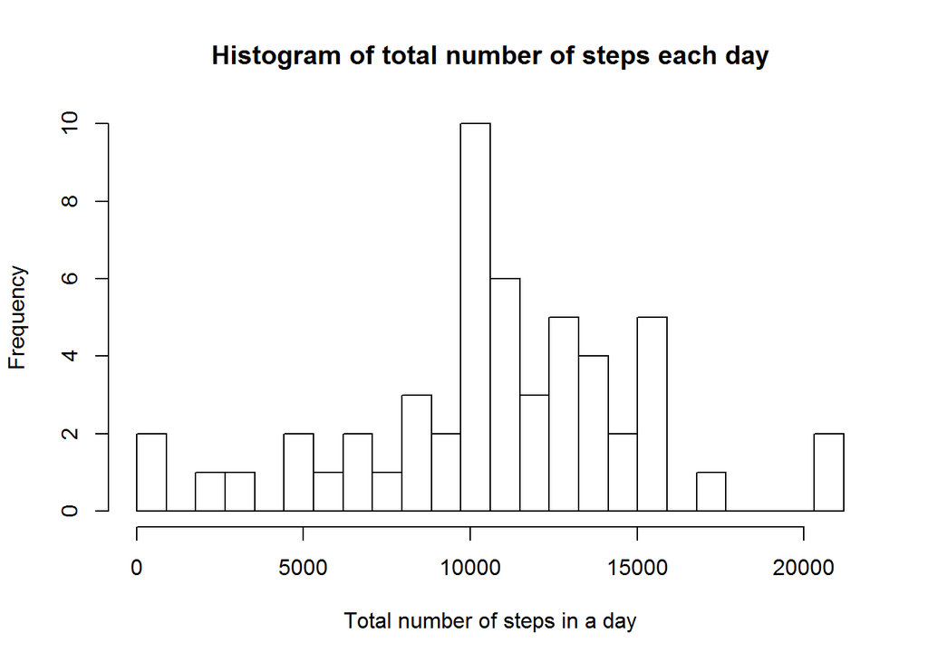

```r
hist(steps_day$steps, breaks=seq(0, max(steps_day$steps), l=25), main = "Histogram of total number of steps each day", xlab="Total number of steps in a day")
```

### 3.Calculate and report the mean and median of the total number of steps taken per day

The summary() function provides descriptive statistics for our variable steps

```r
summary(steps_day$steps)
```

```
##    Min. 1st Qu.  Median    Mean 3rd Qu.    Max.
##      41    8841   10760   10770   13290   21190
```

## What is the average daily activity pattern?

### 1.Make a time series plot of the 5-minute interval (x-axis) and the average number of steps taken, averaged across all days (y-axis)

We make use of the function aggregate() to apply the function mean to the variable “steps” grouped by the factor variable “interval”

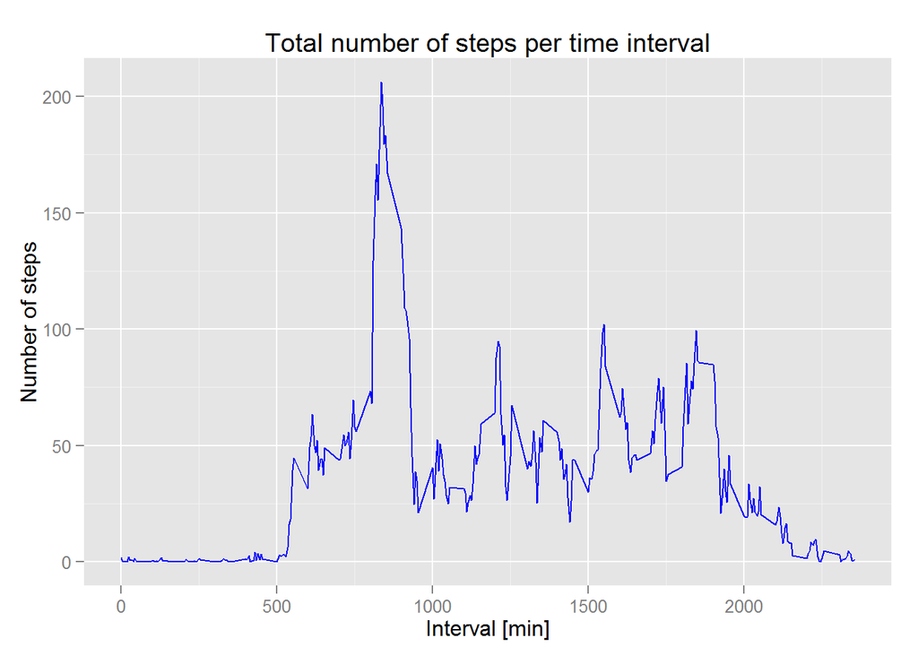

```r
library(ggplot2)

steps_interval <- aggregate(steps ~ interval, activity_data, mean)

ggplot(steps_interval, aes(x=interval, y=steps)) +
  geom_line(stat="identity", colour="blue") +
  guides(fill=FALSE) +
  labs(x="Interval [min]", y="Number of steps") +
  labs(title="Total number of steps per time interval")
```

### 2.Which 5-minute interval, on average across all the days in the dataset, contains the maximum number of steps?

The function which.max provides information about where in an array the maximum values is placed

```r
interval_with_max_steps <- steps_interval[which.max(steps_interval$steps),]
interval_with_max_steps
```

```
##     interval    steps
## 104      835 206.1698
```

## Imputing missing values

### 1.Calculate and report the total number of missing values in the dataset

```r
missing <- sum(is.na(activity_data$steps))
missing
```

```
## [1] 2304
```

### 2.Devise a strategy for filling in all of the missing values in the dataset. The strategy does not need to be sophisticated.

After replicating the “activity_data” data frame, the “NA” values in the variable “steps” are replaced for the mean of that 5-minute interval

```r
activity_data_filled <- activity_data
activity_data_filled$steps[is.na(activity_data$steps)]<-steps_interval$step
head(activity_data_filled)
```

```
##       steps       date interval
## 1 1.7169811 2012-10-01        0
## 2 0.3396226 2012-10-01        5
## 3 0.1320755 2012-10-01       10
## 4 0.1509434 2012-10-01       15
## 5 0.0754717 2012-10-01       20
## 6 2.0943396 2012-10-01       25
```

### 3.Make a histogram of the total number of steps taken each day. Do these values differ from the estimates from the first part of the assignment?

### What is the impact of imputing missing data on the estimates of the total daily number of steps?

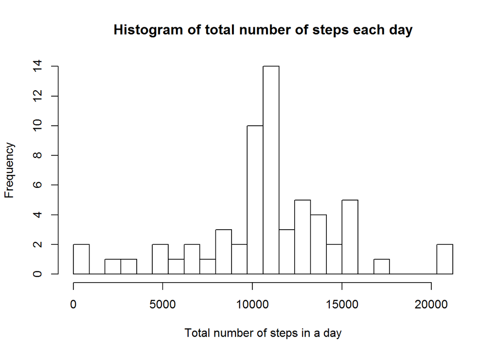

```r
steps_day <- aggregate(steps ~ date, activity_data_filled, sum)

hist(steps_day$steps, breaks=seq(0, max(steps_day$steps), l=25), main = "Histogram of total number of steps each day", xlab="Total number of steps in a day")
```

### Calculate and report the mean and median of the total number of steps taken per day

```r
summary(steps_day$steps)
```

```
##    Min. 1st Qu.  Median    Mean 3rd Qu.    Max.
##      41    9819   10770   10770   12810   21190
```

## Are there differences in activity patterns between weekdays and weekends?

### 1.Create a new factor variable in the dataset with two levels - “weekday” and “weekend” indicating whether a given date is a weekday or weekend day.

```r
library(timeDate)
activity_data_filled$weekday<-isWeekday(activity_data_filled$date, wday = 1:5)

activity_data_filled$weekday[activity_data_filled$weekday==TRUE]<-"weekday"
activity_data_filled$weekday[activity_data_filled$weekday==FALSE]<-"weekend"

activity_data_filled$weekday<-factor(activity_data_filled$weekday)

head(activity_data_filled)
```

```
##       steps       date interval weekday
## 1 1.7169811 2012-10-01        0 weekday
## 2 0.3396226 2012-10-01        5 weekday
## 3 0.1320755 2012-10-01       10 weekday
## 4 0.1509434 2012-10-01       15 weekday
## 5 0.0754717 2012-10-01       20 weekday
## 6 2.0943396 2012-10-01       25 weekday
```

```r
table(activity_data_filled$weekday)
```

```
##
## weekday weekend
##   12960    4608
```

### 2.Make a panel plot containing a time series plot of the 5-minute interval (x-axis) and the average number of steps taken, averaged across all weekday days or weekend days (y-axis).

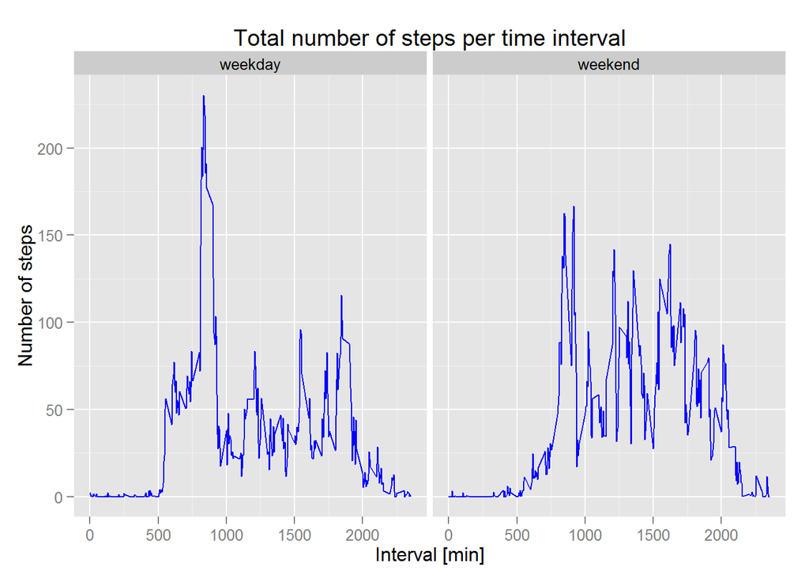

```r
steps_interval <- aggregate(steps ~ interval+weekday, activity_data_filled, mean)

ggplot(steps_interval, aes(x=interval, y=steps)) +
  geom_line(stat="identity", colour="blue", ) +
  guides(fill=TRUE) +
  facet_grid(scales="free", space="free", .~weekday) +
  labs(x="Interval [min]", y="Number of steps") +
  labs(title="Total number of steps per time interval")
```